The contribution of solid in Gibbs energy?(no concentration change)

$\Delta G$ when start from the pure substance, $RT\ln [p]/[R] = -\infty$

# Supervision 2: Thermodynamics

## Problem set

### 9, 10, 11, 15, 18, 19, 22, 23, 24

```python
import math
# constants
R = 8.3145
```

### 9

$$\Delta G = \Delta H -T\Delta S$$

All passed

```python
# (a)
delta_S = -22
delta_H = -6010
T1 = 5 + 273.15
T2 = -5 + 273.15
delta_G1 = delta_H - T1 * delta_S
delta_G2 = delta_H - T2 * delta_S
print("delta G1 = {}, delta G2 = {}".format(delta_G1, delta_G2))

# (b)
T_eq = delta_H / delta_S
print("T_eq = {}".format(T_eq))
```

```
delta G1 = 109.29999999999927, delta G2 = -110.70000000000073
T_eq = 273.1818181818182
```

### 10

Song

#### (a)

G(V)

$$pV = nRT$$ $$\frac{dp}{dV} = -nRT\frac{1}{V^2}$$ $$dG=Vdp=-nRT\frac{1}{V}dV \ (dT = 0)$$

S(V) $$dS = - \frac{dG}{dT}$$

##### Another way

$$\frac{\partial ^2G}{\partial p \partial T} = \frac{\partial ^2G}{\partial T \partial p} $$ $$(\frac{\partial V}{\partial T})_p = -(\frac{\partial S}{\partial p})_T $$

### 11

All passed

#### (a)

\begin{align} \Delta G_\text{mix} & = n_ART\ln(x_A) + n_BRT\ln(x_B) \\ & = x_An_\text{tot}RT\ln(x_A) + x_Bn_\text{tot}RT\ln(x_B) \\ & = n_\text{tot}RT[x_A\ln(x_A) + x_B\ln(x_B)] \end{align}

$$\Delta G_\text{mix}(x_A) = n_\text{tot}RT[x_A\ln(x_A) + (1-x_A)\ln(1-x_A)]$$

#### (b)

$dp = 0$ $$\Delta S_\text{mix} = \left( \frac{\partial \Delta G_\text{mix}}{\partial T} \right)_{p,n} = n_\text{tot}R[x_A\ln(x_A) + (1-x_A)\ln(1-x_A)]$$ $$\Delta H = \Delta G + T\Delta S$$ delta_H = 0, explain?

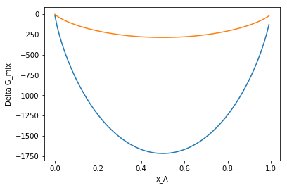

```python
from math import log
%matplotlib inline

import matplotlib.pyplot as plt
import numpy as np

T1 = 298
n = 1
x_A = np.arange(0.001, 1, 0.01)
delta_G1 = n * R * T1 * (x_A * np.log(x_A) + (1 - x_A) * np.log(1 - x_A))
plt.plot(x_A, delta_G1)

T2 = 50
delta_G2 = n * R * T2 * (x_A * np.log(x_A) + (1 - x_A) * np.log(1 - x_A))
plt.plot(x_A, delta_G2)

plt.xlabel('x_A')
plt.ylabel('Delta G_mix')
```

### 15

All passed  
Song, equation

#### (a)

$$\frac{1}{2}N_2 + \frac{3}{2}H_2\rightleftarrows NH_3$$

#### (b)

$$\Delta_rC_p^\circ = A + BT$$

#### (c)

\begin{align} \Delta_rH^\circ(T_2) & = \Delta_rH^\circ(T_1) + \int_{T_1}^{T_2} \Delta_rC_p^\circ (T) dT\\ & = \Delta_rH^\circ(T_1) + A(T_2 - T_1) + \frac{B(T_2^2-T_1^2)}{2} \end{align}

#### (e)

\begin{align} \Delta_rS^\circ(T_2) & = \Delta_rS^\circ(T_1) + \int_{T_1}^{T_2} \frac{\Delta_rC_p^\circ (T)}{T} dT\\ & = \Delta_rS^\circ(T_1) + A(\ln\frac{T_2}{T_1}) + B(T_2 - T_1) \end{align}

```python
# (b)
alpha_N2 = 28.58
alpha_H2 = 27.28
alpha_NH3 = 29.75
beta_N2 = 3.77e-3
beta_H2 = 3.26e-3
beta_NH3 = 25.1e-3

A = alpha_NH3 - 1/2 * alpha_N2 - 3/2 * alpha_H2
B = beta_NH3 - 1/2 * beta_N2 - 3/2 * beta_H2
print("A = {} J/(Kmol), B = {} J/(K^2mol)".format(A, B))

# (d)
T_1 = 298
T_2 = 1000
delta_H_f_1 = -46.1
delta_H_f_2 = delta_H_f_1 * 1000 + A * (T_2 - T_1) + B * (T_2**2 - T_1**2) / 2
print("delta_H_f_2 = {} J/mol = {} kJ/mol".format(delta_H_f_2, delta_H_f_2 / 1000))

# (e)
delta_S_1 = 192.5 * 1 - 130.7 * 3/2 - 191.6 * 1/2
delta_S_2 = delta_S_1 + A * log(T_2 / T_1) + B * (T_2 - T_1)
print("delta_S_1 = {} J/(Kmol)\ndelta_S_2 = {} J/(Kmol)".format(delta_S_1, delta_S_2))
```

```
A = -25.46 J/(Kmol), B = 0.018325 J/(K^2mol)
delta_H_f_2 = -55624.08665 J/mol = -55.624086649999995 kJ/mol
delta_S_1 = -99.34999999999998 J/(Kmol)
delta_S_2 = -117.3092992364576 J/(Kmol)
```

### 18

$$\ln K = \frac{-\Delta_r H^\circ}{RT} + \frac{\Delta_r S ^\circ}{R}$$ approximations

```
k = -12903.506899547112, b = 16.25536855674547
delta_H = 107286.20811628447 J/mol, delta_S = 135.15526186506023 J/(Kmol)
delta_G(700K) = 12677.524810742309 J/mol
```

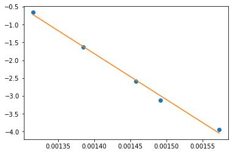

```python
T = np.array([635.7, 670.4, 686.0, 722.2, 760.2])
K = np.array([0.01950, 0.04414, 0.07575, 0.1971, 0.5183])
X = 1/T
Y = np.log(K)
k, b = np.polyfit(X, Y, 1)
plt.plot(X, Y, 'o')
plt.plot(X, k * X + b, '-')
delta_H = - k * R
delta_S = b * R
print("k = {}, b = {}".format(k, b))
print("delta_H = {} J/mol, delta_S = {} J/(Kmol)".format(delta_H, delta_S))

lnK = k * (1/700) + b
delta_G = - R * 700 * lnK
print("delta_G(700K) = {} J/mol".format(delta_G))
# delta_S = (delta_H - delta_G) / 700
```

### 19

#### (a)

$$\ln K_p(T_2) - \ln K_p(T_1) = -\frac{\Delta_rH^\circ}{R}\left(\frac{1}{T_2} - \frac{1}{T_1}\right)$$

#### (b)

$$\Delta_rG^\circ = -RT\ln K = \Delta_rH^\circ - T\Delta_rS^\circ$$
Approximation, Xing

```python
# (b)
K_1 = 1.038e5 # 298K
K_2 = 1.094e4 # 350K
T_1 = 298
T_2 = 350
delta_G = - R * T_1 * log(K_1) # 298K
delta_H = -(log(K_2) - log(K_1)) * R / (1 / T_2 - 1 / T_1)
delta_S = (delta_H - delta_G) / T_1
print("delta_H = {} J/mol\ndelta_G(298K) = {} J/mol\ndelta_S = {} J/(Kmol)".format(delta_H, delta_G, delta_S))
```

```
delta_H = -37523.84858192233 J/mol
delta_G(298K) = -28618.225745062435 J/mol
delta_S = -29.884640392147293 J/(Kmol)
```

### 22

#### (a)

Gibbs-Helmholtz Derivation

#### (b)

Derivation $$\frac{d\ln K}{dT} = \frac{\Delta_rH^\circ}{RT^2}$$

#### (c)

$$\ln K = \frac{11800}{T} - 25.58 - 1.25\ln T$$ $$\frac{d\ln K}{dT} = \frac{-11800 - 1.25T}{T^2}$$ $$\Delta_rH^\circ = R(-11800 - 1.25T)$$

#### (d)

$$C_p(T) = \left(\frac{\partial H}{\partial T}\right)_p$$

```python
T = 500
delta_H = R * (-11800 - 1.25 * T) # 500K
K = math.exp(11800/T - 25.58 - 1.25 * log(T))
delta_G = - R * T * log(K)
delta_S = (delta_H - delta_G) / T

print("delta_H = {} J/mol\ndelta_G(298K) = {} J/mol\ndelta_S = {} J/(Kmol)".format(delta_H, delta_G, delta_S))
print("lnK = {}".format(log(K)))
```

```
delta_H = -103307.6625 J/mol
delta_G(298K) = 40525.954396457055 J/mol
delta_S = -287.66723379291415 J/(Kmol)
lnK = -9.748260123027736
```

### 23

#### (a)

Derivation $$\Delta_rG^\circ = -RT\ln K$$

#### (b)

$$\frac{d\ln K}{dT} = \frac{\Delta_rH^\circ}{RT^2}$$ $$\Delta_rH^\circ = R(2695.2 - 0.03085T^2)$$ $$\Delta_r C_p^\circ(T) = \frac{d\Delta_r H^\circ}{dT} = -2\times 0.03085RT$$

```python
# (b)
T = 300
delta_H = R * (2695.2 - 0.03085 * T**2)
K = math.exp(-2695.2 / T + 7.2877 - 0.03085 * T)
delta_G = - R * T * log(K)
delta_S = (delta_H - delta_G) / T
delta_C_p = -2 * 0.03085 * R * T
print("delta_H = {} J/mol\ndelta_G(300K) = {} J/mol\ndelta_S = {} J/(Kmol)".format(delta_H, delta_G, delta_S))
print("K = {}".format(K))
print("delta_C_p = {} J/(Kmol)".format(delta_C_p))
```

```
delta_H = -675.9688500000016 J/mol
delta_G(300K) = 27316.375155000005 J/mol
delta_S = -93.30781335000002 J/(Kmol)
K = 1.7535204711310285e-05
delta_C_p = -153.901395 J/(Kmol)
```

### 24

Reversible & dp = 0 $$\Delta S = \int_{T_1}^{T_2}\frac{nC_{p,m}}{T}$$

$$\Delta S_\text{surr} = \frac{-q_\text{sys}}{T_\text{sys}}$$

```python
C_p_ice = 37.64
C_p_water = 75.30
delta_H_fusion = 6.024e3 # 273K

delta_H_1 = C_p_water * (273 - 263)
delta_H_2 = -delta_H_fusion
delta_H_3 = C_p_ice * (263 - 273)
delta_H = delta_H_1 + delta_H_2 + delta_H_3

delta_S_1 = C_p_water * log(273 / 263)
delta_S_2 = delta_H_2 / 273
delta_S_3 = C_p_ice * log(263 / 273)
delta_S = delta_S_1 + delta_S_2 + delta_S_3

print("delta_S_1 = {} J/K\ndelta_S_2 = {} J/K\ndelta_S_3 = {} J/K".format(delta_S_1, delta_S_2, delta_S_3))
print("delta_S = {} J/K, delta_H = {} J".format(delta_S, delta_H))

delta_S_sys = delta_S
delta_S_surr = -delta_H / 263
delta_S_univ = delta_S_sys + delta_S_surr
print("delta_S_surr = {} J/K, delta_S_univ = {} J/K".format(delta_S_surr, delta_S_univ))
```

```
delta_S_1 = 2.8100275544418047 J/K
delta_S_2 = -22.065934065934066 J/K
delta_S_3 = -1.404640599590826 J/K
delta_S = -20.660547111083087 J/K, delta_H = -5647.4 J
delta_S_surr = 21.47300380228137 J/K, delta_S_univ = 0.8124566911982818 J/K
```

# Questions

1. Reversible process v.s. Quasi-static process  
   *# Reversible_process*
2. T-S diagram As Carnot cycle can be demonstrated using T-S diagram, how to understand the cycle whose T-S diagram is not a square?  
   Is such process irreversble? If not, what is the irreversible cyclic process like in T-S diagram?  
   *# Reversible_process # T-S diagram*
3. The second law